# Multiple Regression

Dr. Qiusheng Wu

## Forumlas

Specifiy predictors to be included in the formula:

- `lm(formula = y ~ u + v + w)`

Include all predictors:

- `lm(formula = y ~ .)`

Linear regression without an intercept:

- `lm(y ~ x + 0)`

Linear regression with interaction terms:

- `lm(y ~ u*v)`

Backward stepwise regression:

- `full.model <- lm(y ~ x1 + x2 + x3 + x4)`
- `reduced.model <- step(full.model, direction="backward")`

Forward stepwise regression:

- `min.model <- lm(y ~ 1)`
- `fwd.model <- step(min.model, direction="forward", scope=( ~ x1 + x2 + x3 + x4 ))`

## Getting Regression Statistics

Save the regression model in a variable, say `m`:

`m <- lm( y ~ u + v + w)`

The use functions to extract regression statistics and information from the model:

- `anova(m)`: ANOVA table
- `coefficients(m)`: Model coefficients
- `coef(m)`: Same as coefficients(m)
- `confint(m)`: Confidence intervals for the regression coefficients
- `deviance(m)`: Residual sum of squares
- `effects(m)`: Vector of orthogonal effects
- `fitted(m)`: Vector of fitted y values
- `residuals(m)`: Model residuals
- `resid(m)`: Same as residuals(m)
- `summary(m)`: Key statistics, such as $R^2$, the $F$ statistic, and the residual standard error ($\alpha$)
- `vcov(m)`: Variance–covariance matrix of the main parameters

## Multiple Regression

```r
# url <- "http://spatial.binghamton.edu/geog533/data/AlbumSales2.csv"
url <- "AlbumSales2.csv"
df <- read.csv(url,header = TRUE)
df
```

| adverts | sales | airplay | attract |
| --- | --- | --- | --- |
| 10.256 | 330 | 43 | 10 |
| 985.685 | 120 | 28 | 7 |
| 1445.563 | 360 | 35 | 7 |
| 1188.193 | 270 | 33 | 7 |
| 574.513 | 220 | 44 | 5 |
| 568.954 | 170 | 19 | 5 |
| 471.814 | 70 | 20 | 1 |
| 537.352 | 210 | 22 | 9 |
| 514.068 | 200 | 21 | 7 |
| 174.093 | 300 | 40 | 7 |

[output cut: 190 more lines]

```r
m <- lm(sales ~ adverts + airplay + attract, data = df)
# m <- lm(sales ~ ., data = df)
summary(m)
```

```
Call:
lm(formula = sales ~ adverts + airplay + attract, data = df)

Residuals:
     Min       1Q   Median       3Q      Max
-121.324  -28.336   -0.451   28.967  144.132

Coefficients:
              Estimate Std. Error t value Pr(>|t|)
(Intercept) -26.612958  17.350001  -1.534    0.127
adverts       0.084885   0.006923  12.261  < 2e-16 ***
airplay       3.367425   0.277771  12.123  < 2e-16 ***
attract      11.086335   2.437849   4.548 9.49e-06 ***
---
Signif. codes:  0 ‘***’ 0.001 ‘**’ 0.01 ‘*’ 0.05 ‘.’ 0.1 ‘ ’ 1

Residual standard error: 47.09 on 196 degrees of freedom
Multiple R-squared:  0.6647,    Adjusted R-squared:  0.6595
F-statistic: 129.5 on 3 and 196 DF,  p-value: < 2.2e-16
```

```r
anova(m)
```

```
Analysis of Variance Table

Response: sales
           Df Sum Sq Mean Sq F value    Pr(>F)
adverts     1 433688  433688 195.600 < 2.2e-16 ***
airplay     1 381836  381836 172.214 < 2.2e-16 ***
attract     1  45853   45853  20.681 9.492e-06 ***
Residuals 196 434575    2217
---
Signif. codes:  0 ‘***’ 0.001 ‘**’ 0.01 ‘*’ 0.05 ‘.’ 0.1 ‘ ’ 1
```

```r
coefficients(m)
```

```
 (Intercept)      adverts      airplay      attract
-26.61295836   0.08488483   3.36742517  11.08633520
```

```r
coef(m)
```

```
 (Intercept)      adverts      airplay      attract
-26.61295836   0.08488483   3.36742517  11.08633520
```

```r
a <- round(coef(m)[1],2)
b1 <- round(coef(m)[2],2)
b2 <- round(coef(m)[3],2)
b3 <- round(coef(m)[4],2)
```

## Categorical Predictors

[American Median Household Incomes By Race:](http://www.businessinsider.com/heres-median-income-in-the-us-by-race-2013-9)

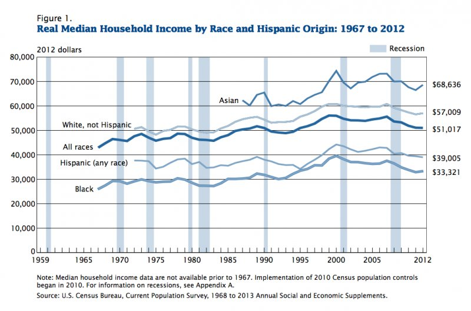

Imgur

```r
set.seed(100)
race <- c(rep("Asian",50),rep("White",50),rep("Hispanic",50),rep("Black",50))
income <- c(rnorm(50,68636,10000),rnorm(50,57009),rnorm(50,39005,10000),rnorm(50,33321,10000))
df <- data.frame(income,race)
df <- df[sample(1:nrow(df)),]
df
```

|  | income | race |
| --- | --- | --- |
| 103 | 34313.53 | Hispanic |
| 56 | 57009.98 | White |
| 72 | 57007.94 | White |
| 87 | 57009.22 | White |
| 158 | 32332.17 | Black |
| 102 | 52636.14 | Hispanic |
| 136 | 43435.71 | Hispanic |
| 164 | 41267.80 | Black |
| 163 | 31548.28 | Black |
| 75 | 57006.94 | White |

[output cut: 190 more lines]

```r
tapply(df$income, df$race, median)
```

```
   Asian    Black Hispanic    White
69304.33 33264.95 36328.17 57008.92
```

```r
m <- lm(income~race,data = df)
summary(m)
```

```
Call:
lm(formula = income ~ race, data = df)

Residuals:
     Min       1Q   Median       3Q      Max
-21639.2  -3229.0     -0.3   2345.3  22287.9

Coefficients:
             Estimate Std. Error t value Pr(>|t|)
(Intercept)   69451.1      981.4  70.765  < 2e-16 ***
raceBlack    -34909.4     1388.0 -25.152  < 2e-16 ***
raceHispanic -31444.0     1388.0 -22.655  < 2e-16 ***
raceWhite    -12442.2     1388.0  -8.964 2.48e-16 ***
---
Signif. codes:  0 ‘***’ 0.001 ‘**’ 0.01 ‘*’ 0.05 ‘.’ 0.1 ‘ ’ 1

Residual standard error: 6940 on 196 degrees of freedom
Multiple R-squared:  0.811, Adjusted R-squared:  0.8081
F-statistic: 280.3 on 3 and 196 DF,  p-value: < 2.2e-16
```

```r
a <- round(coef(m)[1],0)
b1 <- round(coef(m)[2],0)
b2 <- round(coef(m)[3],0)
b3 <- round(coef(m)[4],0)
# income = 69451 - 34909*Black - 31444*Hispanic - 12442*White
summary(df$race)
```

```
   Asian    Black Hispanic    White
      50       50       50       50
```

```r
levels(df$race)
```

```
[1] "Asian"    "Black"    "Hispanic" "White"
```

```r
contrasts(df$race) <- contr.treatment(4,base = 2)
df$race
```

```
  [1] Hispanic White    White    White    Black    Hispanic Hispanic Black    Black    White
 [11] Asian    Hispanic White    Black    Asian    Black    Asian    Hispanic Hispanic Hispanic
 [21] Black    White    Hispanic Black    Asian    Black    Asian    Black    Asian    Asian
 [31] Black    Asian    White    Asian    Black    Black    Hispanic Black    White    Hispanic
 [41] Asian    Asian    White    Black    White    Hispanic White    White    Hispanic Asian
 [51] Asian    Black    Hispanic Black    Black    White    Hispanic White    Hispanic Asian
 [61] White    Hispanic Black    Hispanic White    Hispanic Asian    Asian    Black    Asian
 [71] Black    White    Asian    Asian    Black    Hispanic Black    Black    White    White
 [81] Black    Black    Hispanic Asian    Black    White    Hispanic Hispanic Black    Black
 [91] Hispanic Hispanic Asian    Hispanic Asian    White    Black    Black    Black    Black
[101] Asian    White    Hispanic Hispanic Hispanic Asian    Hispanic Asian    White    Black
[111] White    Black    Asian    Asian    White    Black    Asian    Black    Asian    White
[121] Asian    White    White    Black    White    Hispanic Black    Hispanic White    Asian
[131] Hispanic White    Hispanic Hispanic Asian    Hispanic Hispanic White    Hispanic Hispanic
[141] White    White    Black    Hispanic White    White    Asian    White    Asian    White
[151] Black    Asian    White    White    White    Hispanic Asian    Hispanic White    White
[161] Hispanic Black    Asian    Asian    White    Asian    White    Hispanic Asian    Hispanic
[171] Black    Hispanic Black    White    Asian    Hispanic Asian    Black    Asian    White
[181] Hispanic Asian    Asian    Asian    Asian    White    Black    Black    Black    Hispanic
[191] Asian    White    Hispanic Asian    Black    Black    Asian    White    Black    Hispanic
attr(,"contrasts")
         1 3 4
Asian    1 0 0
Black    0 0 0
Hispanic 0 1 0
White    0 0 1
Levels: Asian Black Hispanic White
```

```r
m <- lm(income~race,data = df)
summary(m)
```

```
Call:
lm(formula = income ~ race, data = df)

Residuals:
     Min       1Q   Median       3Q      Max
-21639.2  -3229.0     -0.3   2345.3  22287.9

Coefficients:
            Estimate Std. Error t value Pr(>|t|)
(Intercept)  34541.7      981.4  35.195   <2e-16 ***
race1        34909.4     1388.0  25.152   <2e-16 ***
race3         3465.5     1388.0   2.497   0.0134 *
race4        22467.2     1388.0  16.187   <2e-16 ***
---
Signif. codes:  0 ‘***’ 0.001 ‘**’ 0.01 ‘*’ 0.05 ‘.’ 0.1 ‘ ’ 1

Residual standard error: 6940 on 196 degrees of freedom
Multiple R-squared:  0.811, Adjusted R-squared:  0.8081
F-statistic: 280.3 on 3 and 196 DF,  p-value: < 2.2e-16
```

```r
# income = 34541 + 34909*Asian + 3465*Hispanic + 22467*White
```